# **Recommender Engine**

[figure not shown]

Linkedln Learning platform is a large-scale content recommendation engine developed by the organization’s AI team. The learning platform currently serves over 690 LinkedIn members and customers based on a hyper-personalized model to help learners access courses based on their personal and professional developmental interests. LinkedIn’s expansion to online learning platforms began with purchasing Lynda.com educational database. In acquiring Lynda’s database, the AI team developed core features that corporations can easily learn, network, and recruit skilled employees.

### *Scenario Design*

1. **Target Users:** LinkedIn Learning targets individual learners and enterprise employees. The online learning platform is designed to engage and empower learners in supporting a strategic development path. See the image below showing a sample LinkedIn Learning user homepage.
2. **Key Goals:** LinkedIn Learning key goal is to provide an online platform that is available and accessible from anywhere and whenever the users need it.
3. **Accomplishing these goals (minimizing churn):** In my view, the LinkedIn Learning recommender engine introduced a user-friendly online platform to assist individual learning goals and provided a skills development platform to enterprises existing and onboarding employees. In the area of improvements, I align with Shorgov’s recommendation that LikedIn Learning’s continual expansion will require the incorporation of higher quality accreditations and certifications from universities or institutions.

[figure not shown]

### *System Overview*

LinkedIn Learning recommender system performs scenario design twice. The system is designed in two layers: online and offline, and process recommendations for the organization and the organization’s customers. The system design as seen below, the offline layer computes each member’s personalized data with a rank listing and is stored in an online key-value store. The online layer provides recommendations to the learners by leveraging the A/B testing framework (LinkedIn, Part 1.).

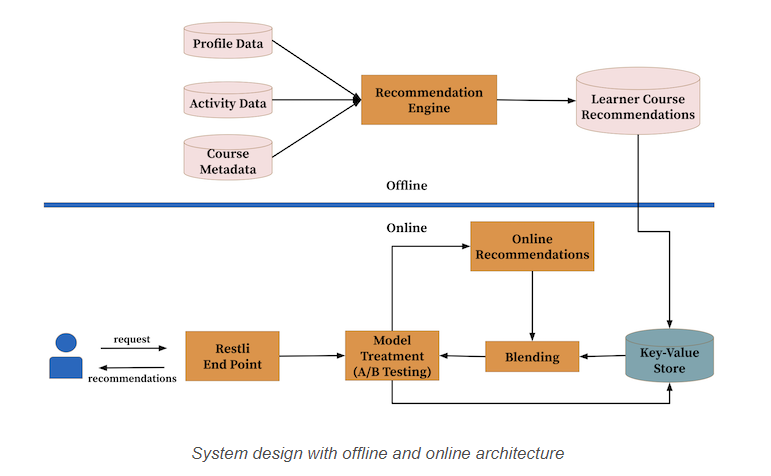

### *Recommendation Algorithms*

The major blocks for LinkedIn algorithms are *Response Prediction and Collaborative Filtering*. With learners’ contextual information, an analysis will gauge how explicit/implicit learners are engaged about the courses.

*P(engagement | learner, course) = ?*

1. **Response Prediction:** Chaudhari, indicates a response prediction model uses learner and course features, as well as explicit one-time engagement (clicks, bookmarks, etc.), as labels to generate recommendations.
2. **Collaborative Filtering:** LinkedIn AI team adopted the Deep Neural Network-based CF algorithm approach for the benefits of capturing multiple layers in the neural network that untangles complex relationships based on a learner’s engagement data. The algorithm removes outliners based on viewers course watch time to consider course relevance.

### *Conclusion*

LinkedIn Learning is building a competitive learning platform geared toward professionals and enterprises. The knowledge-based recommender engine analyzes the user data in two formats, offline and online, to provide matching co-watching patterns based on layered user analysis. In my opinion, LinkedIn Learning course recommendations should expand to accreditations with higher learning institutions to build a degree pathway. The marketability feature of a degree pathway will a valuable asset for the user and enterprise.

##### *References:*

A closer look at the AI behind course recommendations on LinkedIn Learning, Part 1. (n.d.). Engineering.linkedin.com. Retrieved November 2, 2021, from https://engineering.linkedin.com/blog/2020/course-recommendations-ai-part-one

A closer look at the AI behind course recommendations on LinkedIn Learning, Part 2. (n.d.). Engineering.linkedin.com. Retrieved November 2, 2021, from https://engineering.linkedin.com/blog/2020/course-recommendations-ai-part-two

Atanas Shorgov. (2020, March 15). How LinkedIn Learning Reached 17 Million Users in 4 Years. Medium; Better Marketing. https://bettermarketing.pub/how-linkedin-learning-reached-17-million-users-in-4-years-59657ac55721